# Lecture 39: Updating Probabilities

Associated Textbook Sections: [18.0 - 18.2](https://ccsf-math-108.github.io/textbook/chapters/18/Updating_Predictions.html)

## Outline

- Decisions
- Conditional Probability
- Tree Diagrams
- Bayes' Rule
- Subjective Probabilities

## Set Up the Notebook

```python
from datascience import *
import numpy as np
%matplotlib inline
import matplotlib.pyplot as plt
plt.style.use('fivethirtyeight')
```

## Decisions Under Uncertainty

### Scenario: Medical Testing

[*Interpretation by Physicians of Clinical Laboratory Results (1978)*](https://www.nejm.org/doi/full/10.1056/nejm197811022991808)

> We asked 20 house officers, 20 fourth-year medical students and 20 attending physicians, selected in 67 consecutive hallway encounters at four Harvard Medical School teaching hospitals, the following question:

> *If a test to detect a disease whose prevalence is 1/1000 has a false positive rate of 5%, what is the chance that a person found to have a positive result actually has the disease, assuming that you know nothing about the person's symptoms or signs?*

> Eleven of 60 participants, or 18%, gave the correct answer. These participants included four of 20 fourth-year students, three of 20 residents in internal medicine and four of 20 attending physicians. The most common answer, given by 27, was that [the chance that a person found to have a positive result actually has the disease] was 95%.
- Rare disease with prevalence of 1/1000 in population
- There is a test (e.g., antigen test) with the following properties
  - False Positive Rate of 5%: If you do NOT have the disease then 5% of the time, the test says you do.
  - False Negative Rate of 1%: If you DO have the disease then 1% of the time, the test says you do not have the disease.
- If you sample a person at random and they test positive, what is the chance they have the rare disease?

### Truth and Test Results

All patients fall into one of 4 categories:

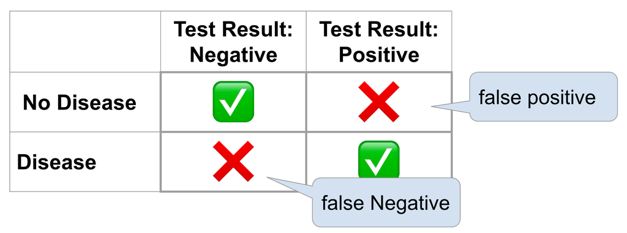

### False Positive Rate

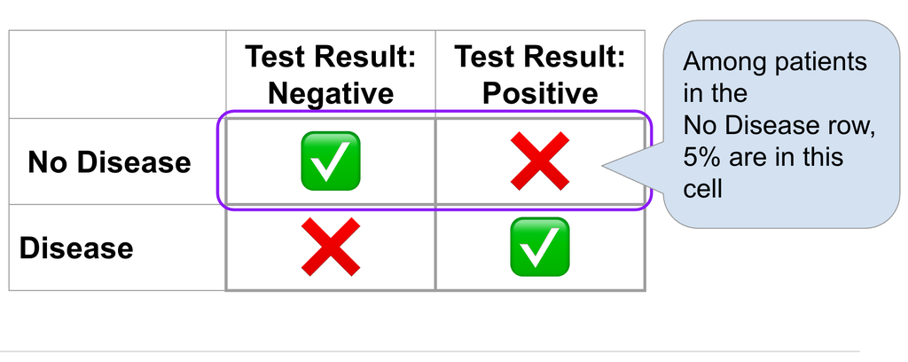

### False Negative Rate

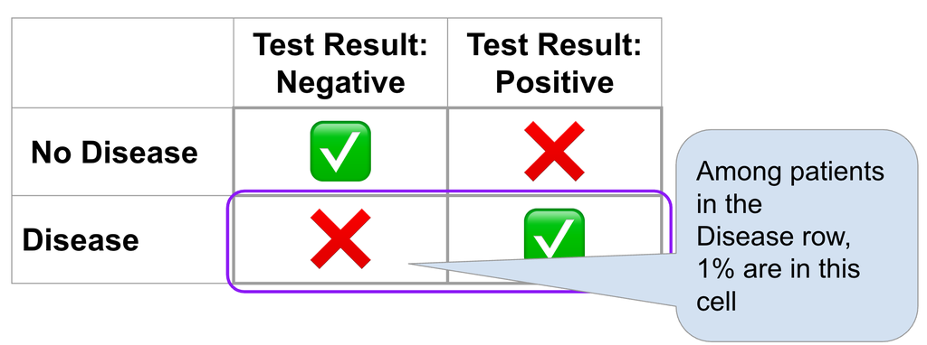

## Unconditional and Conditional Probabilities

### Scenario: Education

#### Background

- Class consists of Freshmen (60%) and Sophomores (40%)
- Some of the students have declared their major
  - 50% of the Freshmen have declared their major
  - 80% of the Sophomores have declared their major

#### Unconditional Probability

- If I pick one student at random ...
- What is the chance they are a Sophomore?
  - **Unconditional probability** of being a sophomore
  - No additional information is given
  - The probability that the student is a sophomore is 40%.

#### Conditional Probability

- If I pick one **Sophomore** student at random ...
- **Given Information: That student is a sophomore!**
- What is the chance that they have declared a major?
  - **Conditional probability** of declaring a major, given that the student is a Sophomore.
  - The probability that the student (who is a Sophomore) has declared a major is 80%.

#### Another Conditional Probability

- If I pick one student who **declared a major** at random...
- **Given Information: That student has declared a major!**
- What is the chance they are a Sophomore?
  - **Conditional probability** of being a sophomore, given that the student has declared a major.
  - The probability that the student (who declared a major) is a sophomore is ... ???

## Conditional Probability

### What do these scenarios have in common?

- There is some chance event that I am interested in
  - person has a disease
  - the student's year
- I start with some prior (before observing anything) information about that quantity:
  - P(Disease)
  - P(Year)
- I then observe something whose value depends probabilistically on the original chance event:
  - Test is Positive
  - Student has declared
  - Neither piece of information exactly determines the original event
- How do I update the probability of the original event given the additional information?

### Conditional Probability

- Probability of an event given some information (it is conditioned on the information)
- Example:
  - “80% of Sophomores are Declared”
  - P(Declared | Sophomore) = 0.8 ← Notation

### Conditional vs Joint Probabilities

- The **joint probability** of two events:
  - P(Declared, Sophomore) = chance of a random student being a declared and a Sophomore
- The **conditional probability** (the stuff after | is given):
  - P(Declared | Sophomore) = chance of a random Sophomore student being declared
- Which one is bigger? Let's see.

### Example: Comparing Conditional and Joint Probabilities

```python
from IPython.display import IFrame
IFrame('https://docs.google.com/presentation/d/e/2PACX-1vRiLsFDsuuT\
_fGEkjNJJ5Yv6MdEkWshYniIDyrzR4F4vN7UkAUgwT-MrhUTy8_gxwyhLv3rTleNScXw\
/embed?start=false&loop=false&delayms=3000', 960, 569)
```

[interactive chart not shown]

## Tree Diagrams

### Tree Diagrams

```python
from IPython.display import IFrame
IFrame('https://docs.google.com/presentation/d/e/2PACX-1vTYqt2\
-0qckaBNAHfug29S4o0IV-tCrPkOp3a01wWsx65iyAmpFX3gI9ROkaZ21Syf77\
xyiIIDrGAgS/embed?start=false&loop=false&delayms=3000', 960, 569)
```

[interactive chart not shown]

## Bayes' Rule

### Bayes' Rule

```python
from IPython.display import IFrame
IFrame('https://docs.google.com/presentation/d/e/2PACX-1vSTI_AHfonqA-\
ww_uTioJOpF_sy8PHvEkaZ1B0ahy-KdKXygejBtQeQpIACZ0xNLnEYCfTbfkSC3Klw/\
embed?start=false&loop=false&delayms=3000', 960, 569)
```

[interactive chart not shown]

### A Closer Look at the Answer

Assume a patient is picked at random.

- Prior probability of disease
  - P(Disease) = 0.001 = one-tenth of 1%
- Posterior probability of disease given positive test
  - P(Disease | Test positive) = 0.0194... ≅ 2%
- Bigger than the prior, but still pretty small
- Should we approve such a test?
  - The test has low error rates compared to most tests
- How can this be?

### Bayes' Rule and Covid Testing

[figure not shown]

> "Without knowing the prior probability, you don't know how likely it is that a result is false or true."

> The government says – accurately – that the “false positive rate”, the chance of a test returning a positive result in a person who does not have the disease, is less than one in 1,000. And that’s where we came in: you might think that that means, if you’ve had a positive result, that there’s a less than one in 1,000 chance that it’s false.

### Demo: Bayes' Rule

- Create a function that calculates $P(A \mid B) = \frac{P(A) \cdot P(B\mid A)}{P(B)}$
- Use `bayes_rule` to calculate the probability for the original medical question.
- How does the conditional probability change when the prior is larger?
- Notice how quickly the Posterior probability climbs as the Prior probability increases.

```python
def bayes_rule(pr_a, pr_b_given_a, pr_b_given_not_a):
    """
    Bayes' Rule
    P(A | B) = P(A)P(B|A) / P(B)

    To Compute P(B)
        P(B) = P(B, A) + P(B, Not A)
             = P(A)P(B|A) + P(Not A)P(B | Not A)
    """
    pr_b = pr_b_given_a * pr_a + pr_b_given_not_a * (1 - pr_a)
    return pr_a * pr_b_given_a / pr_b
```

```python
pr_disease = 1/1000
pr_pos_given_disease = 0.99
pr_pos_given_no_disease = 0.05

bayes_rule(pr_disease, pr_pos_given_disease, pr_pos_given_no_disease)
```

```
0.019434628975265017
```

```python
pr_disease_update = 10/1000
pr_pos_given_disease = 0.99
pr_pos_given_no_disease = 0.05

bayes_rule(pr_disease_update, pr_pos_given_disease, pr_pos_given_no_disease)
```

```
0.16666666666666669
```

```python
pr_disease = np.arange(1,999)/1000
pr_pos_given_disease = 0.99
pr_pos_given_no_disease = 0.05

post = bayes_rule(pr_disease, pr_pos_given_disease, pr_pos_given_no_disease)
Table().with_columns(
    "Prior Pr(Disease)", pr_disease,
    "Posterior Pr(Disease | Pos. Test)", post).iplot("Prior Pr(Disease)")
```

[interactive chart not shown]

## Subjective Probabilities

### Perspectives

- The probability of an outcome can be defined from several different perspectives, such as:
  - Objective:
    - *Classical*: The number of favorable outcomes divided by the number of total possible outcomes
    - *Frequentist*: The frequency with which it will occur in repeated trials
  - Subjective:
    - *Bayesian*: Someone's subjective degree of belief that it will occur
- We've utilized the objective perspectives several times
  - Defining chance by relying solely on data
  - Does not incorporate personal beliefs or opinions
  - For example:
    - Applying basic probability rules to situations involving playing cards
    - Performing hypothesis testing using many simulations
- Why use the subjective perspective?
  - To quantify a belief that is relevant to a decision or opinion
  - To quantify your degree of uncertainty about an outcome, even when there is no physical randomization
    - The chance of the ["Big One"](https://en.wikipedia.org/wiki/San_Andreas_Fault#The_next_.22Big_One.22) in the next 30 years

## Attribution

This content is licensed under the Creative Commons Attribution-NonCommercial-ShareAlike 4.0 International License (CC BY-NC-SA 4.0) and derived from the Data 8: The Foundations of Data Science offered by the University of California, Berkeley.